# STAT 301 - Group 20

```r
library(tidyverse)
```

```r
set.seed(30120)
```

```r
data <- read.table('dataset-uci.csv', header = TRUE, sep = ",", stringsAsFactors = FALSE)

colnames(data) <- colnames(data) %>%
tolower() %>%
str_replace_all("\\s+", "_") %>%
str_replace_all("[^a-z0-9_]", "") %>%
str_replace("^([0-9])", "x\\1")
data %>% head()
cat("Column names:\n")
colnames(data)

cat("\nNumber of columns:\n")
print(length(colnames(data)))

cat("\nNumber of rows:\n")
print(nrow(data))
```

A data.frame: 6 × 39

|  | xgallstonestatus <int> | age <int> | gender <int> | comorbidity <int> | coronaryarterydiseasecad <int> | hypothyroidism <int> | hyperlipidemia <int> | diabetesmellitusdm <int> | height <int> | weight <dbl> | ... | highdensitylipoproteinhdl <dbl> | triglyceride <dbl> | aspartataminotransferazast <dbl> | alaninaminotransferazalt <dbl> | alkalinephosphatasealp <dbl> | creatinine <dbl> | glomerularfiltrationrategfr <dbl> | creactiveproteincrp <dbl> | hemoglobinhgb <dbl> | vitamind <dbl> |
| --- | --- | --- | --- | --- | --- | --- | --- | --- | --- | --- | --- | --- | --- | --- | --- | --- | --- | --- | --- | --- | --- |
| 1 | 0 | 50 | 0 | 0 | 0 | 0 | 0 | 0 | 185 | 92.8 | ... | 40 | 134 | 20 | 22 | 87 | 0.82 | 112.47 | 0 | 16.0 | 33.0 |
| 2 | 0 | 47 | 0 | 1 | 0 | 0 | 0 | 0 | 176 | 94.5 | ... | 43 | 103 | 14 | 13 | 46 | 0.87 | 107.10 | 0 | 14.4 | 25.0 |
| 3 | 0 | 61 | 0 | 0 | 0 | 0 | 0 | 0 | 171 | 91.1 | ... | 43 | 69 | 18 | 14 | 66 | 1.25 | 65.51 | 0 | 16.2 | 30.2 |
| 4 | 0 | 41 | 0 | 0 | 0 | 0 | 0 | 0 | 168 | 67.7 | ... | 59 | 53 | 20 | 12 | 34 | 1.02 | 94.10 | 0 | 15.4 | 35.4 |
| 5 | 0 | 42 | 0 | 0 | 0 | 0 | 0 | 0 | 178 | 89.6 | ... | 30 | 326 | 27 | 54 | 71 | 0.82 | 112.47 | 0 | 16.8 | 40.6 |
| 6 | 0 | 96 | 0 | 0 | 0 | 0 | 0 | 0 | 155 | 49.0 | ... | 30 | 65 | 13 | 13 | 60 | 1.46 | 43.74 | 0 | 11.0 | 45.8 |

```
Column names:
```

1. 'xgallstonestatus'

2. 'age'

3. 'gender'

4. 'comorbidity'

5. 'coronaryarterydiseasecad'

6. 'hypothyroidism'

7. 'hyperlipidemia'

8. 'diabetesmellitusdm'

9. 'height'

10. 'weight'

11. 'bodymassindexbmi'

12. 'totalbodywatertbw'

13. 'extracellularwaterecw'

14. 'intracellularwatericw'

15. 'extracellularfluidtotalbodywaterecftbw'

16. 'totalbodyfatratiotbfr'

17. 'leanmasslm'

18. 'bodyproteincontentprotein'

19. 'visceralfatratingvfr'

20. 'bonemassbm'

21. 'musclemassmm'

22. 'obesity'

23. 'totalfatcontenttfc'

24. 'visceralfatareavfa'

25. 'visceralmuscleareavmakg'

26. 'hepaticfataccumulationhfa'

27. 'glucose'

28. 'totalcholesteroltc'

29. 'lowdensitylipoproteinldl'

30. 'highdensitylipoproteinhdl'

31. 'triglyceride'

32. 'aspartataminotransferazast'

33. 'alaninaminotransferazalt'

34. 'alkalinephosphatasealp'

35. 'creatinine'

36. 'glomerularfiltrationrategfr'

37. 'creactiveproteincrp'

38. 'hemoglobinhgb'

39. 'vitamind'

[output not shown]

### Dataset Summary

- **Dataset name:** Gallstone-1
- **Source:** [UCI Machine Learning Repository](https://archive.ics.uci.edu/dataset/1150/gallstone-1)
- **Number of observations:** 319
- **Number of variables:** 39

| Variable | Description | Type |
| --- | --- | --- |
| xgallstonestatus | Presence of gallstones | Categorical |
| age | Age | Numeric |
| gender | Gender | Categorical |
| comorbidity | Presence of comorbid diseases | Categorical |
| coronaryarterydiseasecad | Coronary artery disease status | Categorical |
| hypothyroidism | Hypothyroidism status | Categorical |
| hyperlipidemia | Hyperlipidemia status | Categorical |
| diabetesmellitusdm | Diabetes mellitus status | Categorical |
| height, weight, bodymassindexbmi | Anthropometric measures | Numeric |
| totalbodywatertbw, extracellularwaterecw, intracellularwatericw, extracellularfluidtotalbodywaterecftbw | Body water and fluid distribution metrics | Numeric |
| totalbodyfatratiotbfr, leanmasslm, bodyproteincontentprotein, visceralfatratingvfr, bonemassbm, musclemassmm, obesity, totalfatcontenttfc, visceralfatareavfa, visceralmuscleareavmakg | Body composition metrics | Numeric |
| hepaticfataccumulationhfa | Liver fat accumulation indicator | Numeric |
| glucose, totalcholesteroltc, lowdensitylipoproteinldl, highdensitylipoproteinhdl, triglyceride | Blood biochemistry | Numeric |
| aspartataminotransferazast, alaninaminotransferazalt, alkalinephosphatasealp, creatinine, glomerularfiltrationrategfr, creactiveproteincrp, hemoglobinhgb, vitamind | Liver and kidney biomarkers | Numeric |

### Pre-selection of Variables

Some variables are highly correlated or redundant and we may remove. I grouped some of these variables above but here are some more concrete examples:

- `height` and `weight` are represented by `bodymassindexbmi`
- `totalbodywatertbw`, `extracellularwaterecw`, and `intracellularwatericw` are collinear measures of hydration
- There's some scientific terms I don't really understand, but some prelimary factors showed that variables under binary comorbidity indicators (`coronaryarterydiseasecad`, `diabetesmellitusdm`, etc.) can be summed into a single index as they represent the same thing

# Scientific Question

### The question I'll aim for is:

We want to examine the association between a person's total body water (L) (response) and predictors related to lean mass, gender and body fat ratio and other proportional measurements.

**Response variable:** `totalbodywatertbw`

**Explanatory variables:** `leanmasslm`, `totalbodyfatratiotbfr`, `gender`, `height`, `weight`, `bmi`

**Model type:** Multiple Linear Regression

**Focus:** Inference — to identify which body composition features contribute most to totalbodywatertbw

# Section 3: EDA and Visualization

```r
df <- read.table('dataset-uci.csv', header = TRUE, sep = ",", stringsAsFactors = FALSE)

colnames(df) <- colnames(df) %>%
tolower() %>%
str_replace_all("\\s+", "_") %>%
str_replace_all("[^a-z0-9_]", "") %>%
str_replace("^([0-9])", "x\\1")

# Convert categorical variables to factors
df <- df %>%
  mutate(
    gender = as.factor(gender),
    comorbidity = as.factor(comorbidity),
    hepaticfataccumulationhfa = as.factor(hepaticfataccumulationhfa)
  )

df$gender <- factor(df$gender,
                  levels = c(0, 1),
                  labels = c("Male", "Female"))


df %>% head()
```

A data.frame: 6 × 39

|  | xgallstonestatus <int> | age <int> | gender <fct> | comorbidity <fct> | coronaryarterydiseasecad <int> | hypothyroidism <int> | hyperlipidemia <int> | diabetesmellitusdm <int> | height <int> | weight <dbl> | ... | highdensitylipoproteinhdl <dbl> | triglyceride <dbl> | aspartataminotransferazast <dbl> | alaninaminotransferazalt <dbl> | alkalinephosphatasealp <dbl> | creatinine <dbl> | glomerularfiltrationrategfr <dbl> | creactiveproteincrp <dbl> | hemoglobinhgb <dbl> | vitamind <dbl> |
| --- | --- | --- | --- | --- | --- | --- | --- | --- | --- | --- | --- | --- | --- | --- | --- | --- | --- | --- | --- | --- | --- |
| 1 | 0 | 50 | Male | 0 | 0 | 0 | 0 | 0 | 185 | 92.8 | ... | 40 | 134 | 20 | 22 | 87 | 0.82 | 112.47 | 0 | 16.0 | 33.0 |
| 2 | 0 | 47 | Male | 1 | 0 | 0 | 0 | 0 | 176 | 94.5 | ... | 43 | 103 | 14 | 13 | 46 | 0.87 | 107.10 | 0 | 14.4 | 25.0 |
| 3 | 0 | 61 | Male | 0 | 0 | 0 | 0 | 0 | 171 | 91.1 | ... | 43 | 69 | 18 | 14 | 66 | 1.25 | 65.51 | 0 | 16.2 | 30.2 |
| 4 | 0 | 41 | Male | 0 | 0 | 0 | 0 | 0 | 168 | 67.7 | ... | 59 | 53 | 20 | 12 | 34 | 1.02 | 94.10 | 0 | 15.4 | 35.4 |
| 5 | 0 | 42 | Male | 0 | 0 | 0 | 0 | 0 | 178 | 89.6 | ... | 30 | 326 | 27 | 54 | 71 | 0.82 | 112.47 | 0 | 16.8 | 40.6 |
| 6 | 0 | 96 | Male | 0 | 0 | 0 | 0 | 0 | 155 | 49.0 | ... | 30 | 65 | 13 | 13 | 60 | 1.46 | 43.74 | 0 | 11.0 | 45.8 |

# Plot

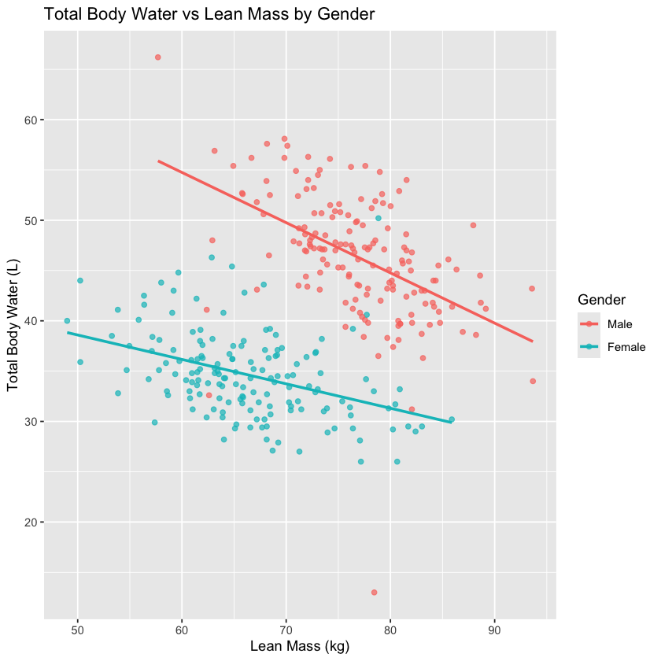

```r
ggplot(df, aes(x = leanmasslm, y = totalbodywatertbw, color = gender)) +
  geom_point(alpha = 0.7) +
  geom_smooth(method = "lm", se = FALSE) +
  labs(
    title = "Total Body Water vs Lean Mass by Gender",
    x = "Lean Mass (kg)",
    y = "Total Body Water (L)",
    color = "Gender"
  )
```

**Relevancy**:

This plot is relevant as it let's us explore how much as someone get's more lean mass, how is this assocaited with how much water is in their body. We also want to see how this changes between gender

**Results:**

I originally thought that these would have positive relationships but interestingly, the total amount of water decreases with lean mass (negative relationship).

We can also see that for males, the slope is more significant meaning that for every additional kg of lean mass, there's less L of total water in the body compared to females.

**What did we learn?**

Overall, the plot indicates that lean mass and total body water are inversely associated, and gender shifts the overall TBW level upward for males relative to females and will also provide a more significant slope. This suggests there's an interaction term here we can look at. I'm also curious on the negative relationship since I thought it would be more mass -> bigger -> more water.